# FLOW

```r
setwd('C:/Users/user/Documents')
setwd("./complete")
```

# Flow.time 유동인구 데이터 – 시간별 유동인구와 미세먼지

##### 필요한 라이브러리 로드

```r
library(tidyverse)
```

##### 필요한 데이터 로드

```r
flow.time.kgb = as_tibble(read.csv("flowtime동별gb_kweather.csv"))
flow.sexage.kgb = as_tibble(read.csv("flow.sexage동별gb_kweather.csv"))
```

##### 노원구는 미세먼지가 나쁜 날 유동인구가 적은 반면, 종로구는 유동인구가 더 많아지는 특정 시간대가 존재했다. 특히 주말의 새벽 2시와 주말의 점심에 미세먼지가 나쁨에도 유동인구가 더 많았다.

```r
colnames(flow.time.kgb)[4:27] = 0:23
flow.time.kgb2 = flow.time.kgb %>% gather( c(paste0(0:23)) , key = 'TIME', value = "FLOW" )
flow.time.kgb2$TIME = factor(flow.time.kgb2$TIME, levels = 0:23)
flow.time.kgb2
```

```
## # A tibble: 5,184 x 5
##    HDONG       weekend gb    TIME      FLOW
##    <fct>       <fct>   <fct> <fct>    <dbl>
##  1 J청운효자동 주중    kbad  0      482.
##  2 J청운효자동 주중    kgood 0      557.
##  3 J청운효자동 주중    ratio 0        0.866
##  4 J청운효자동 주말    kbad  0      612.
##  5 J청운효자동 주말    kgood 0      653.
##  6 J청운효자동 주말    ratio 0        0.937
##  7 J사직동     주중    kbad  0     1414.
##  8 J사직동     주중    kgood 0     1669.
##  9 J사직동     주중    ratio 0        0.847
## 10 J사직동     주말    kbad  0     1833.
## # ... with 5,174 more rows
```

```r
flow.time.kgb3 = flow.time.kgb2 %>% separate(HDONG, c("GU", "HHDONG"), c(1))

ja = round(table(flow.time.kgb3  %>% filter(gb == 'ratio', weekend == '주중', GU == 'J', FLOW >= 1) %>% select(TIME))/17 , 3)
jb = round(table(flow.time.kgb3  %>% filter(gb == 'ratio', weekend == '주말', GU == 'J', FLOW >= 1) %>% select(TIME))/17 , 3)

jaa =  table(flow.time.kgb3  %>% filter(gb == 'ratio', weekend == '주중', GU == 'J', FLOW >= 1) %>% select(TIME))
jbb = table(flow.time.kgb3  %>% filter(gb == 'ratio', weekend == '주말', GU == 'J', FLOW >= 1) %>% select(TIME))


na = round(table(flow.time.kgb3  %>% filter(gb == 'ratio', weekend == '주중', GU == 'N', FLOW >= 1) %>% select(TIME))/19 , 3)
nb = round(table(flow.time.kgb3  %>% filter(gb == 'ratio', weekend == '주말', GU == 'N', FLOW >= 1) %>% select(TIME))/19 , 3)

naa =  table(flow.time.kgb3  %>% filter(gb == 'ratio', weekend == '주중', GU == 'N', FLOW >= 1) %>% select(TIME))
nbb =  table(flow.time.kgb3  %>% filter(gb == 'ratio', weekend == '주말', GU == 'N', FLOW >= 1) %>% select(TIME))

jab = rbind(jaa,ja,jbb,jb)
rownames(jab) = c('종로구 주중 count', '종로구 주중 percent', '종로구 주말 count', '종로구 주말 percent')
jab
```

```
##                         0     1      2     3      4     5     6     7
## 종로구 주중 count   5.000 8.000  7.000 7.000 11.000 8.000 5.000 5.000
## 종로구 주중 percent 0.294 0.471  0.412 0.412  0.647 0.471 0.294 0.294
## 종로구 주말 count   5.000 4.000 13.000 5.000  8.000 7.000 1.000 4.000
## 종로구 주말 percent 0.294 0.235  0.765 0.294  0.471 0.412 0.059 0.235
##                         8     9     10     11     12     13     14     15
## 종로구 주중 count   3.000 5.000  6.000  7.000  9.000 10.000  7.000  5.000
## 종로구 주중 percent 0.176 0.294  0.353  0.412  0.529  0.588  0.412  0.294
## 종로구 주말 count   5.000 5.000 10.000 10.000 14.000 12.000 12.000 13.000
## 종로구 주말 percent 0.294 0.294  0.588  0.588  0.824  0.706  0.706  0.765
##                         16    17    18    19    20    21    22    23
## 종로구 주중 count    7.000 5.000 3.000 2.000 2.000 5.000 3.000 3.000
## 종로구 주중 percent  0.412 0.294 0.176 0.118 0.118 0.294 0.176 0.176
## 종로구 주말 count   14.000 7.000 2.000 2.000 4.000 4.000 3.000 2.000
## 종로구 주말 percent  0.824 0.412 0.118 0.118 0.235 0.235 0.176 0.118
```

```r
write.csv(jab, '종로구 flowtime table.csv')

nab = rbind(naa,na,nbb,nb)
nab
```

```
##         0     1     2     3     4     5     6     7     8     9    10
## naa 3.000 3.000 3.000 5.000 5.000 4.000 1.000 2.000 3.000 5.000 6.000
## na  0.158 0.158 0.158 0.263 0.263 0.211 0.053 0.105 0.158 0.263 0.316
## nbb 5.000 5.000 6.000 8.000 5.000 4.000 1.000 3.000 3.000 4.000 4.000
## nb  0.263 0.263 0.316 0.421 0.263 0.211 0.053 0.158 0.158 0.211 0.211
##        11    12    13    14    15    16    17    18    19    20    21
## naa 6.000 7.000 8.000 7.000 6.000 5.000 5.000 5.000 1.000 1.000 4.000
## na  0.316 0.368 0.421 0.368 0.316 0.263 0.263 0.263 0.053 0.053 0.211
## nbb 5.000 8.000 8.000 8.000 9.000 8.000 6.000 3.000 2.000 2.000 2.000
## nb  0.263 0.421 0.421 0.421 0.474 0.421 0.316 0.158 0.105 0.105 0.105
##        22    23
## naa 2.000 2.000
## na  0.105 0.105
## nbb 2.000 2.000
## nb  0.105 0.105
```

```r
rownames(nab) = c('노원구 주중 count', '노원구 주중 percent', '노원구 주말 count', '노원구 주말 percent')

write.csv(nab, '노원구 flowtime table.csv')
```

##### 주말 미세먼지가 나쁘면 사람들이 잘 돌아다니지 않을 것이라 생각했으나, 종로구 몇 지역에서 미세먼지가 나쁠때가 좋을 때보다 유동인구가 늘어난 이유는 무엇일까?

##### 종로구는 직장지&관광지가 많다는 특징이 있다.

##### 특히 삼청동이 다른 구에 비해, 주말의 미세먼지가 나쁜 날 유동인구가 늘어난다. 삼청동은 관광지다. 사람들은 미세먼지에 개의치 않고 돌아다니는 듯 하다. 아래 그래프는 주말에, 미세먼지가 나쁜날, 좋은날 ratio를 동별로 시간별로 본 그래프이다.

```r
colnames(flow.time.kgb)[4:27] = 0:23
flow.time.kgb
```

```
## # A tibble: 216 x 27
##    HDONG weekend gb        `0`     `1`     `2`     `3`     `4`     `5`
##    <fct> <fct>   <fct>   <dbl>   <dbl>   <dbl>   <dbl>   <dbl>   <dbl>
##  1 J청운효~ 주중    kbad  4.82e+2 3.25e+2 239.    206.    3.86e+2 8.09e+2
##  2 J청운효~ 주중    kgood 5.57e+2 3.93e+2 288.    249.    4.07e+2 8.33e+2
##  3 J청운효~ 주중    ratio 8.66e-1 8.26e-1   0.830   0.830 9.47e-1 9.71e-1
##  4 J청운효~ 주말    kbad  6.12e+2 4.31e+2 332.    253.    3.00e+2 3.95e+2
##  5 J청운효~ 주말    kgood 6.53e+2 4.78e+2 364.    282.    3.27e+2 4.56e+2
##  6 J청운효~ 주말    ratio 9.37e-1 9.03e-1   0.913   0.895 9.17e-1 8.66e-1
##  7 J사직동~ 주중    kbad  1.41e+3 9.04e+2 619.    545.    1.30e+3 3.21e+3
##  8 J사직동~ 주중    kgood 1.67e+3 1.08e+3 775.    669.    1.35e+3 3.27e+3
##  9 J사직동~ 주중    ratio 8.47e-1 8.35e-1   0.799   0.815 9.66e-1 9.81e-1
## 10 J사직동~ 주말    kbad  1.83e+3 1.23e+3 921.    701.    8.46e+2 1.85e+3
## # ... with 206 more rows, and 18 more variables: `6` <dbl>, `7` <dbl>,
## #   `8` <dbl>, `9` <dbl>, `10` <dbl>, `11` <dbl>, `12` <dbl>, `13` <dbl>,
## #   `14` <dbl>, `15` <dbl>, `16` <dbl>, `17` <dbl>, `18` <dbl>,
## #   `19` <dbl>, `20` <dbl>, `21` <dbl>, `22` <dbl>, `23` <dbl>
```

```r
flow.time.kgb2 = flow.time.kgb %>% gather( c(paste0(0:23)) , key = 'TIME', value = "FLOW" )

flow.time.kgb2$TIME = factor(flow.time.kgb2$TIME, levels = 0:23)

flow.time.kgb2
```

```
## # A tibble: 5,184 x 5
##    HDONG       weekend gb    TIME      FLOW
##    <fct>       <fct>   <fct> <fct>    <dbl>
##  1 J청운효자동 주중    kbad  0      482.
##  2 J청운효자동 주중    kgood 0      557.
##  3 J청운효자동 주중    ratio 0        0.866
##  4 J청운효자동 주말    kbad  0      612.
##  5 J청운효자동 주말    kgood 0      653.
##  6 J청운효자동 주말    ratio 0        0.937
##  7 J사직동     주중    kbad  0     1414.
##  8 J사직동     주중    kgood 0     1669.
##  9 J사직동     주중    ratio 0        0.847
## 10 J사직동     주말    kbad  0     1833.
## # ... with 5,174 more rows
```

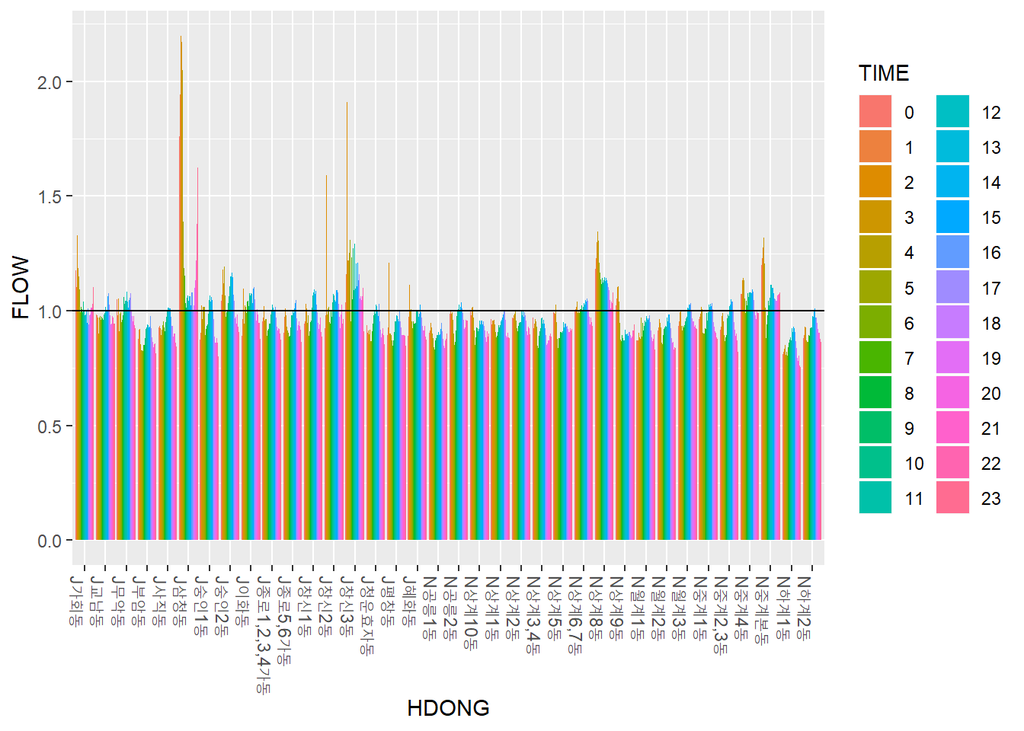

```r
flow.time.kgb2 %>% filter(gb == 'ratio', weekend == '주말') %>%
  ggplot(aes(HDONG, FLOW, fill = TIME)) +
  geom_bar(stat = 'identity', position=position_dodge()) +
  geom_hline(yintercept=1) +
  theme(axis.text.x = element_text(angle = 270, hjust = 0))
```

# Flow.time 유동인구 데이터

# – 미세먼지가 좋은날, 나쁜날 평균 유동인구의 비교. 동별, 주중주말별.

##### 미세먼지가 나쁜날 유동인구 평균 / 미세먼지가 좋은날 유동인구 평균 ratio를, 동별로 주중 주말별로 살펴보았다.

##### 주말과 주중에 그렇게 큰 차이는 없다. 또한 대부분 동의 ratio가 푸른 선인 0.9를 넘는다. 따라서 미세먼지가 나쁘다고 해서 유동인구가 상대적으로 크게 줄어들진 않는다.

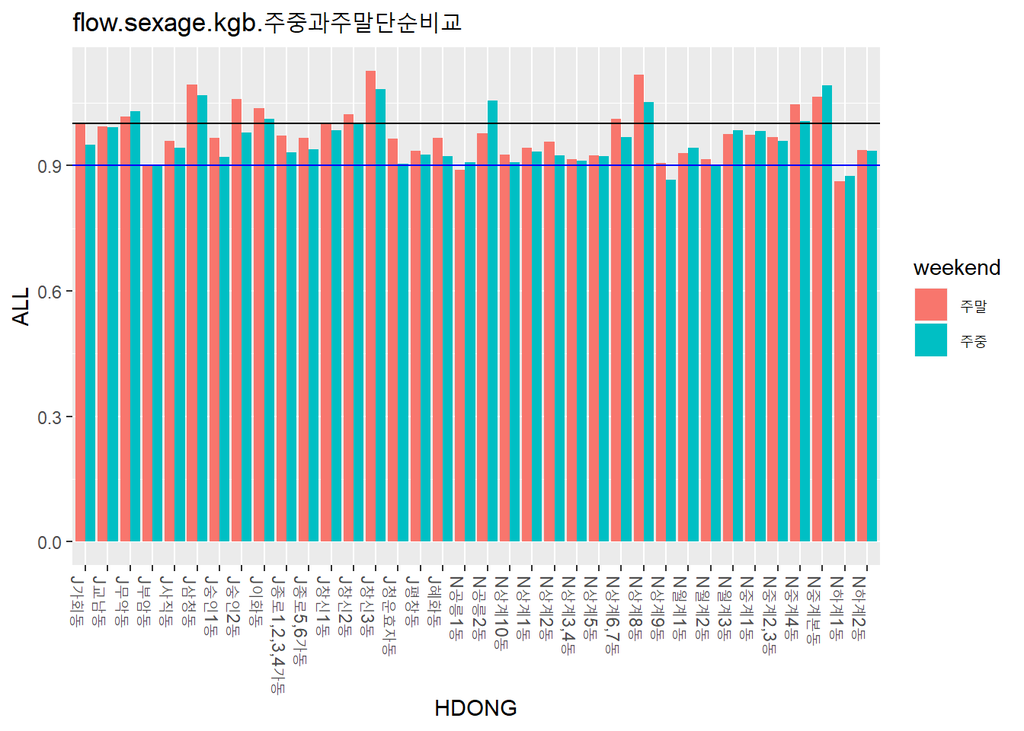

```r
flow.sexage.kgb  %>% filter(gb == "ratio") %>% ggplot(aes(HDONG, ALL)) +
  geom_bar(stat = 'identity', aes(fill = weekend), position=position_dodge()) +
  geom_hline(yintercept=1) +geom_hline(yintercept=0.9, color = 'blue') +
  ggtitle("flow.sexage.kgb.주중과주말단순비교") +
   theme(axis.text.x = element_text(angle = 270, hjust = 0))
```